# #MenstruAcción

Datos 2019 - Septiembre

### Organización y limpieza de los datos

```r
date <- "Septiembre 2019"
```

### Variables del dataset

| names(datos) |
| --- |
| Categoría |
| Marca |
| Nombre |
| Presentación |
| Comercio |
| Sucursal |
| Dirección |
| Localidad |
| Provincia |
| Precio.de.lista |

[output cut: 1 more lines]

#### Categorías

| Categoría | n | porcentaje |
| --- | --- | --- |
| toallitas | 91787 | 79.7% |
| tampones | 23416 | 20.3% |

Esta composición es de la disponibilidad de precios, no refleja la estructura del consumo.

#### Marcas

| Marca | n | porcentaje | acumulado |
| --- | --- | --- | --- |
| SIEMPRE LIBRE | 22603 | 19.6% | 19.6% |
| ALWAYS | 21097 | 18.3% | 37.9% |
| KOTEX | 15663 | 13.6% | 51.5% |
| NOSOTRAS | 11013 | 9.6% | 61.1% |
| LADYSOFT | 8870 | 7.7% | 68.8% |
| OB | 6307 | 5.5% | 74.3% |
| BONTÉ | 5137 | 4.5% | 78.7% |
| O.B. | 5030 | 4.4% | 83.1% |
| CALIPSO | 4626 | 4.0% | 87.1% |
| LINA | 3476 | 3.0% | 90.1% |

[output cut: 21 more lines]

#### Presentación

| Presentación | n | porcentaje | acumulado |
| --- | --- | --- | --- |
| 8.0 un | 56850 | 49.3% | 49.3% |
| 16.0 un | 42343 | 36.8% | 86.1% |
| 20.0 un | 4723 | 4.1% | 90.2% |
| 10.0 un | 4671 | 4.1% | 94.3% |
| 32.0 un | 2796 | 2.4% | 96.7% |
| 24.0 un | 1065 | 0.9% | 97.6% |
| 27.0 un | 844 | 0.7% | 98.3% |
| 1.0 un | 574 | 0.5% | 98.8% |
| 14.0 un | 565 | 0.5% | 99.3% |
| 54.0 un | 317 | 0.3% | 99.6% |

[output cut: 5 more lines]

#### Provincias

| Provincia | n | porcentaje | acumulado |
| --- | --- | --- | --- |
| Buenos Aires | 35901 | 31.2% | 31.2% |
| CABA | 29524 | 25.6% | 56.8% |
| Mendoza | 9562 | 8.3% | 65.1% |
| Córdoba | 8494 | 7.4% | 72.5% |
| Río Negro | 3617 | 3.1% | 75.6% |
| Neuquén | 3150 | 2.7% | 78.3% |
| Entre Ríos | 3032 | 2.6% | 81.0% |
| Chubut | 2648 | 2.3% | 83.3% |
| Salta | 2572 | 2.2% | 85.5% |
| Santa Fe | 2510 | 2.2% | 87.7% |

[output cut: 14 more lines]

#### Regiones

| Region | n | porcentaje | acumulado |
| --- | --- | --- | --- |
| GBA | 65425 | 56.8% | 56.8% |
| PAM | 15067 | 13.1% | 69.9% |
| CUY | 12763 | 11.1% | 80.9% |
| PAT | 12469 | 10.8% | 91.8% |
| NOA | 7802 | 6.8% | 98.5% |
| NEA | 1677 | 1.5% | 100.0% |

#### Precio de lista

Por Categoría

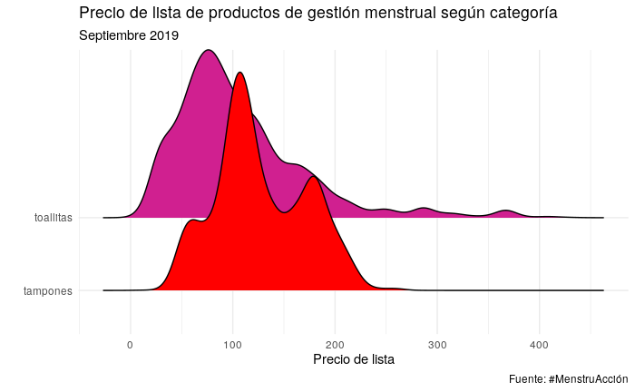

```r
ggplot(datos, aes(x = Precio.de.lista, y = Categoría, fill = Categoría)) +
  geom_density_ridges(scale = 3, bandwidth = 10) +
  theme_minimal() +
  scale_fill_manual(values = c("red", "violetred")) +
  theme(legend.position = "none") +
  labs(title = "Precio de lista de productos de gestión menstrual según categoría",
       subtitle = date,
       x = "Precio de lista",
       y = "",
       caption = "Fuente: #MenstruAcción")
```

Nota: bimodal en tampones debe ser por diferentes presentaciones.

Por Categoría y Regiones

```r
#library(dichromat)
#pal <- colorRampPalette(c("red", "violetred"))(6)
#
#ggplot(datos, aes(x = Precio.de.lista, y = Region, fill = Region)) +
#  geom_density_ridges(scale = 2, bandwidth = 10) +
#  theme_minimal() +
#  scale_fill_manual(values = pal)+
#  facet_wrap(. ~ Categoría) +
#  theme(legend.position = "none")
```

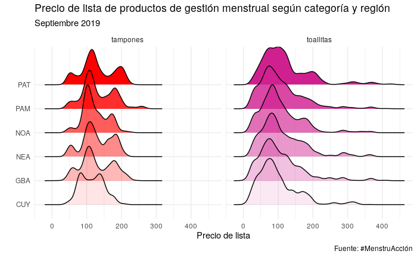

```r
ggplot(datos, aes(x = Precio.de.lista, y = Region, fill = Categoría, alpha = Region)) +
  geom_density_ridges(scale = 2, bandwidth = 10) +
  theme_minimal() +
  scale_fill_manual(values = c("red", "violetred"))+
  facet_wrap(. ~ Categoría) +
  theme(legend.position = "none") +
  labs(title = "Precio de lista de productos de gestión menstrual según categoría y región",
       subtitle = date,
       x = "Precio de lista",
       y = "",
       caption = "Fuente: #MenstruAcción")
```

#### Limpieza de la cantidad de unidades (Presentación)

Modifico la variable Presentación, para quedarme con las unidades en formato numérico.

| unidades | n | porcentaje | acumulado |
| --- | --- | --- | --- |
| 8 | 56850 | 49.3% | 49.3% |
| 16 | 42343 | 36.8% | 86.1% |
| 20 | 4723 | 4.1% | 90.2% |
| 10 | 4671 | 4.1% | 94.3% |
| 32 | 2796 | 2.4% | 96.7% |
| 24 | 1065 | 0.9% | 97.6% |
| 27 | 844 | 0.7% | 98.3% |
| 1 | 574 | 0.5% | 98.8% |
| 14 | 565 | 0.5% | 99.3% |
| 54 | 317 | 0.3% | 99.6% |

[output cut: 5 more lines]

Hay casos que, de acuerdo a la descripción en Nombre, tienen mal la cantidad de unidades en Presentacion (y por ende en unidades), afectando el calculo de precios unitarios.

Utilizando expresiones regulares me quedo con los dígitos, sean uno o más, que están seguidos de “Un” o “un”.

| unidades.regex | n | porcentaje | acumulado |
| --- | --- | --- | --- |
| 8 | 57262 | 49.7% | 49.7% |
| 16 | 43116 | 37.4% | 87.1% |
| 20 | 4878 | 4.2% | 91.4% |
| 10 | 4671 | 4.1% | 95.4% |
| 32 | 2796 | 2.4% | 97.8% |
| 24 | 1065 | 0.9% | 98.8% |
| 14 | 565 | 0.5% | 99.3% |
| 30 | 400 | 0.3% | 99.6% |
| 7 | 294 | 0.3% | 99.9% |
| NA | 148 | 0.1% | 100.0% |

[output cut: 3 more lines]

Vamos a prescindir de los valores faltantes en unidades.regex

```r
unidades.faltantes <- datos %>%
  filter(is.na(unidades.regex)) %>%
  select(Nombre, unidades.regex, Presentación, unidades) %>%
  group_by(Nombre, unidades.regex, Presentación, unidades) %>%
  summarise(n())

datos <- datos %>%
  filter(!is.na(unidades.regex))

kable(unidades.faltantes) %>%
  kable_styling(bootstrap_options = "striped",
                full_width = F)
```

| Nombre | unidades.regex | Presentación | unidades | n() |
| --- | --- | --- | --- | --- |
| Toalla Femenina Cola Less Calipso Plus Pack | NA | 8.0 un | 8 | 136 |
| Toalla Femenina Normal sin Alas Calipso Plus 8 | NA | 1.0 un | 1 | 12 |

Verificamos aquellos casos en que unidades.regex (que surge del texto en Nombre) no coincide con la variable unidades (que surge de la variable Presentación).

```r
verif <- datos %>%
  filter(unidades.regex != unidades) %>%
  group_by(Nombre, unidades, unidades.regex) %>%
  summarise(n=n()) %>%
  arrange(-n)

kable(verif) %>%
  kable_styling(bootstrap_options = "striped",
                full_width = F)
```

| Nombre | unidades | unidades.regex | n |
| --- | --- | --- | --- |
| Toalla Femenina Normal Suave Aloe con Alas Ladysoft 16 Un | 27 | 16 | 644 |
| Toalla Femenina Invisible Natural Nosotras 30 Un | 1 | 30 | 400 |
| Toallas Femeninas Nocturna Ladysoft 8 Un | 16 | 8 | 227 |
| Toallita Femenina Normal con Alas Ladysoft 8 Un | 54 | 8 | 225 |
| Toalla Femenina con Alas Ladysoft 16 Un | 27 | 16 | 200 |
| Toalla Femenina con Alas Slim Ladysoft 16 Un | 1 | 16 | 158 |
| Tampones Medio OB 20 Un | 12 | 20 | 155 |
| Toalla Femenina Normal Aloe Ladysoft 8 Un | 54 | 8 | 92 |
| Toallitas con Manzanilla Calipso 8 Un | 50 | 8 | 2 |
| Toallitas Femenina Esencial Ultrafinas con Alas Days 8 Un | 16 | 8 | 2 |

Las cantidades referidas a las unidades por paquete parecen ser mejor captadas con el método de regex sobre el texto del Nombre del producto, respecto de lo surgido de la información de la página como Presentación. Nos quedaremos con unidades.regex para calcular el precio por unidad de los productos.

```r
# Descarto las variables que no voy a usar
datos <- datos %>%
  select(-Presentación, -Comercio, -Sucursal, -Dirección, -Localidad, -unidades)
```

#### Precio por unidad

Creo la variable precio.por.unidad a partir del Precio.de.lista y las unidades.regex.

Por Categoría

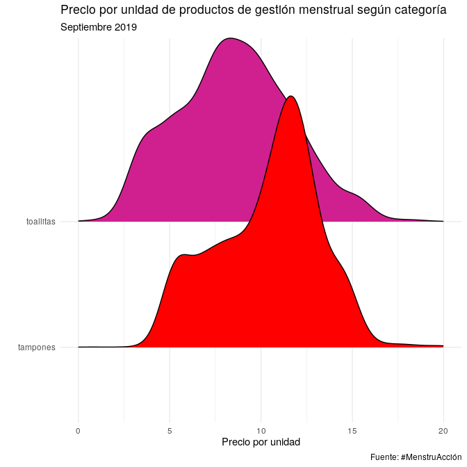

```r
ggplot(datos, aes(x = precio.por.unidad, y = Categoría, fill = Categoría)) +
  geom_density_ridges(scale = 2, bandwidth = 0.75) +
  theme_minimal() +
  scale_x_continuous(limits = c(0, 20)) +
  scale_fill_manual(values = c("red", "violetred")) +
  theme(legend.position = "none") +
  labs(title = "Precio por unidad de productos de gestión menstrual según categoría",
       subtitle = date,
       x = "Precio por unidad",
       y = "",
       caption = "Fuente: #MenstruAcción")
```

Por Categoría y Regiones

```r
reg_ordenadas <- datos %>%
  group_by(Region) %>%
  summarise(promedio = mean(precio.por.unidad)) %>%
  arrange(promedio) %$% Region

datos <- datos %>%
  mutate(Region = factor(Region, levels = reg_ordenadas))
```

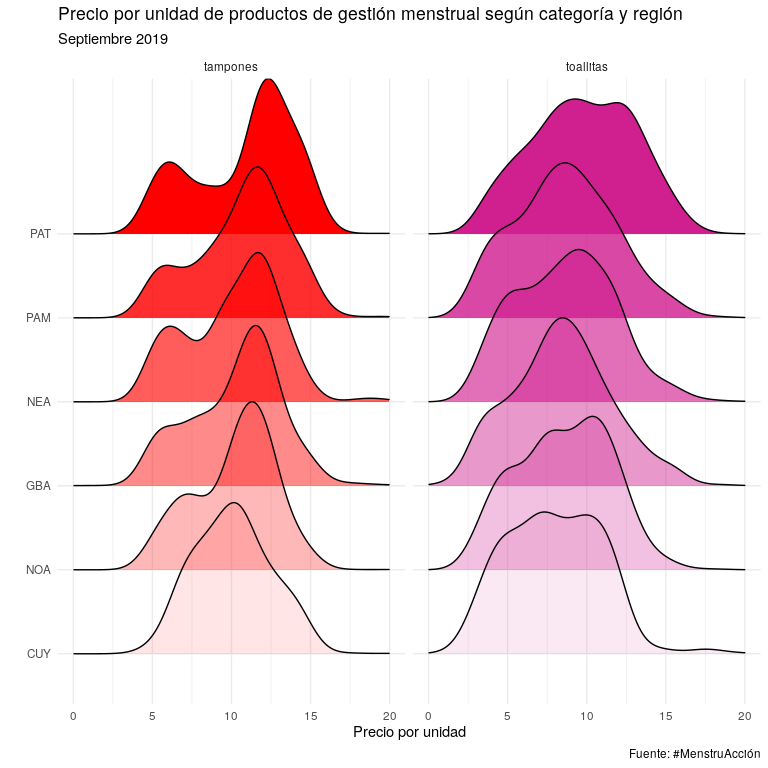

```r
ggplot(datos, aes(x = precio.por.unidad, y = Region, fill = Categoría, alpha = Region)) +
  geom_density_ridges(scale = 2, bandwidth = 1) +
  theme_minimal() +
  scale_fill_manual(values = c("red", "violetred"))+
  facet_wrap(. ~ Categoría) +
  theme(legend.position = "none") +
  scale_x_continuous(limits = c(0, 20)) +
  labs(title = "Precio por unidad de productos de gestión menstrual según categoría y región",
       subtitle = date,
       x = "Precio por unidad",
       y = "",
       caption = "Fuente: #MenstruAcción")
```

Ordenadas de menor a mayor precio promedio las regiones  
**Nota:** La distribución se parece mucho a la de GBA porque es la que más pesa en los datos.

#### 2,5 % de los extremos de la distribución

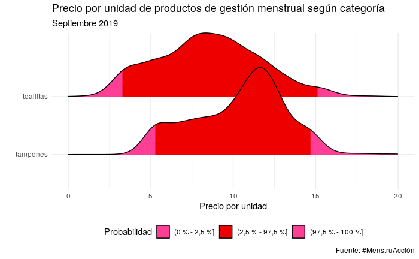

```r
ggplot(datos, aes(x = precio.por.unidad, y = Categoría, fill = factor(..quantile..))) +
  stat_density_ridges(geom = "density_ridges_gradient",
                      calc_ecdf = TRUE, quantiles = c(0.025, 0.975),
                      bandwidth = 0.75, scale = 1.5) +
  scale_fill_manual(name = "Probabilidad",
                    values = c("violetred1", "red2", "violetred1"),
                    labels = c("(0 % - 2,5 %]", "(2,5 % - 97,5 %]", "(97,5 % - 100 %]")) +
  scale_x_continuous(limits = c(0, 20)) +
  theme_minimal() +
  theme(legend.position = "bottom") +
  labs(title = "Precio por unidad de productos de gestión menstrual según categoría",
       subtitle = paste(date),
       x = "Precio por unidad",
       y = "",
       caption = "Fuente: #MenstruAcción")
```

```r
prov_ordenadas <- datos %>%
  group_by(Provincia) %>%
  summarise(promedio = mean(precio.por.unidad)) %>%
  arrange(promedio) %$%
  Provincia

datos <- datos %>%
  mutate(Provincia = factor(Provincia, levels = prov_ordenadas))
```

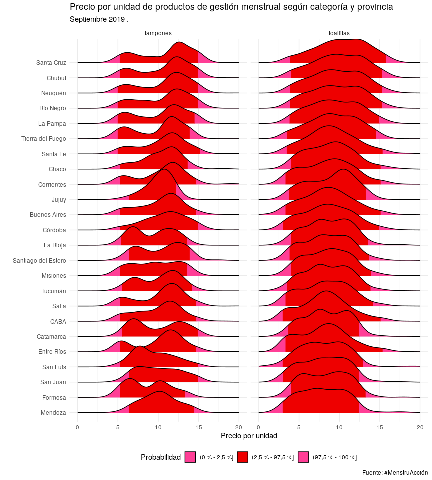

Ordenadas las provincias por precio promedio, de menor a mayor.

Cargo la estimación, por provincia, de personas que menstrúan. Esto sale de las proyecciones poblacionales del INDEC para 2019, teniendo en cuenta que la menarca se estima en los 13 años y la menopausia en 49 años. Estos datos se van a utilizar para ponderar el precio promedio de cada provincia a la hora de agregar en un indicador nacional.

Además, considerando que hay outliers (valores atípicos) en los precios unitarios, a la hora de calcular los promedios de precios provinciales remuevo las colas, utilizando una media alfa podada:

- alfa = 2.5%

# Resultados

## Total Nacional

### Toallitas

- Precio promedio por unidad

```
[1] "Toallitas: El precio promedio por unidad es de $ 8.63"
```

- Gasto por año por persona

Teniendo en cuenta:  
ciclos por año: 13  
productos utilizados por ciclo: 22

```
[1] "Toallitas: El gasto promedio por año por persona es de $ 2467.95"
```

### Tampones

- Precio promedio por unidad

```
[1] "Tampones: El precio promedio por unidad es de $ 10.37"
```

- Gasto por año por persona

Teniendo en cuenta:  
ciclos por año: 13  
productos utilizados por ciclo: 22

```
[1] "Tampones: El gasto promedio por año por persona es de $ 2965.68"
```

## Por provincia

### Toallitas

Gasto por año por persona, según provincia

| Provincia | gasto.por.anio |
| --- | --- |
| Mendoza | 2243.73 |
| Formosa | 2379.01 |
| San Juan | 2294.83 |
| San Luis | 2347.59 |
| Entre Ríos | 2337.74 |
| Catamarca | 2397.41 |
| CABA | 2368.16 |
| Salta | 2391.22 |
| Tucumán | 2436.68 |
| Misiones | 2458.10 |

[output cut: 14 more lines]

### Tampones

Gasto por año por persona, según provincia

| Provincia | gasto.por.anio |
| --- | --- |
| Mendoza | 2899.81 |
| Formosa | 2494.41 |
| San Juan | 2889.90 |
| San Luis | 2689.78 |
| Entre Ríos | 2912.79 |
| Catamarca | 2862.91 |
| CABA | 2887.83 |
| Salta | 2979.77 |
| Tucumán | 2891.17 |
| Misiones | 2772.64 |

[output cut: 14 more lines]

#### Aumentos

**A precios de marzo 2019:**

- Toallitas: El precio promedio por unidad es de $6.75
- Tampones: El precio promedio por unidad es de $7.44

Aumento unitario toallitas

```r
valor.toallitas0 <- 6.75
inf_toallitas_un <- (valor.toallitas - valor.toallitas0)/valor.toallitas0 * 100
inf_toallitas_un
```

```
[1] 27.83974
```

Aumento unitario tampones

```r
valor.tampones0 <- 7.44
inf_tampones_un <- (valor.tampones - valor.tampones0)/valor.tampones0 * 100
inf_tampones_un
```

```
[1] 39.37536
```

#### Comparación de la evolución con IPC

Copio los datos de *ipc_marzo_septiembre_2019.xls* (recorte de *sh_ipc_10_19.xls*)

```r
ipc <- tibble::tribble(
                                  ~Mes, ~'Mar-19', ~'Apr-19', ~'May-19', ~'Jun-19', ~'Jul-19', ~'Aug-19', ~'Sep-19',
                       "Nivel General",     206,   213.1,   219.6,   225.5,   230.5,   239.6,   253.7,
  "Alimentos y bebidas no alcohólicas",   210.6,     216,   221.3,   226.9,     232,   242.5,   256.4,
                               "Salud",   210.4,   217.7,   228.8,   236.9,   246.7,   259.5,   281.1
  ) %>%
  gather(.,mes, valor, 2:8) %>%
  spread(.,Mes, valor) %>%
  mutate(mes = lubridate::parse_date_time(mes,orders = 'my')) %>%
  arrange(mes) %>%
  rename(alimentos='Alimentos y bebidas no alcohólicas', general = 'Nivel General', salud=Salud) %>%
  mutate(alimentos = alimentos/first(alimentos)*100,
         general = general/first(general)*100,
         salud = salud/first(salud)*100)

ipc
```

| mes | alimentos | general | salud |
| --- | --- | --- | --- |
| 2019-03-01 | 100.0000 | 100.0000 | 100.0000 |
| 2019-04-01 | 102.5641 | 103.4466 | 103.4696 |
| 2019-05-01 | 105.0807 | 106.6019 | 108.7452 |
| 2019-06-01 | 107.7398 | 109.4660 | 112.5951 |
| 2019-07-01 | 110.1614 | 111.8932 | 117.2529 |
| 2019-08-01 | 115.1472 | 116.3107 | 123.3365 |
| 2019-09-01 | 121.7474 | 123.1553 | 133.6027 |

```r
comparo_variaciones <- ipc %>%
  filter(mes== parse_date('2019-09-01')) %>%
  select(-mes) %>%
  mutate(alimentos = alimentos - 100,
         general = general - 100,
         salud = salud - 100,
         toallitas_un = inf_toallitas_un,
         tampones_un = inf_tampones_un) %>%
  gather(., Grupo, Variacion) %>%
  mutate(Grupo = case_when(Grupo == "general" ~ "Nivel General",
                           Grupo == "alimentos" ~ "Alimentos\n y bebidas\n no alcohólicas",
                           Grupo == "salud" ~ "Salud",
                           Grupo == "toallitas_un" ~ "Toallitas\n (p/u)",
                           Grupo == "tampones_un" ~ "Tampones\n (p/u)"),
         Grupo = factor(Grupo, levels = c("Nivel General",
                                          "Alimentos\n y bebidas\n no alcohólicas",
                                          "Salud",
                                          "Toallitas\n (p/u)",
                                          "Tampones\n (p/u)")),
         Variacion = round(Variacion, 1)) %>%
  arrange(Grupo)

comparo_variaciones
```

| Grupo | Variacion |
| --- | --- |
| Nivel General | 23.2 |
| Alimentos\n y bebidas\n no alcohólicas | 21.7 |
| Salud | 33.6 |
| Toallitas\n (p/u) | 27.8 |
| Tampones\n (p/u) | 39.4 |

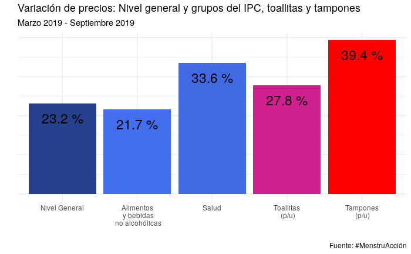

Limites:

- posibles sesgos de la información de la página
- copas?
- no tenemos ponderadores de consumo toallitas/tampones
- algo sobre ingresos (histograma? deciles?)
- población trans (eph y censo 2020)
- comparación IPC general, leche u otros productos